# INN Hotels Project

## Data Preprocessing

- Missing value treatment (if needed)
- Feature engineering (if needed)
- Outlier detection and treatment (if needed)
- Preparing data for modeling
- Any other preprocessing steps (if needed)

**Data Preprocessing Notes**

- We checked during Data Overview for missing values and did not find any.
- Except for dummy variable, no Feature Engineering is needed
- We still need to create dummy variables.

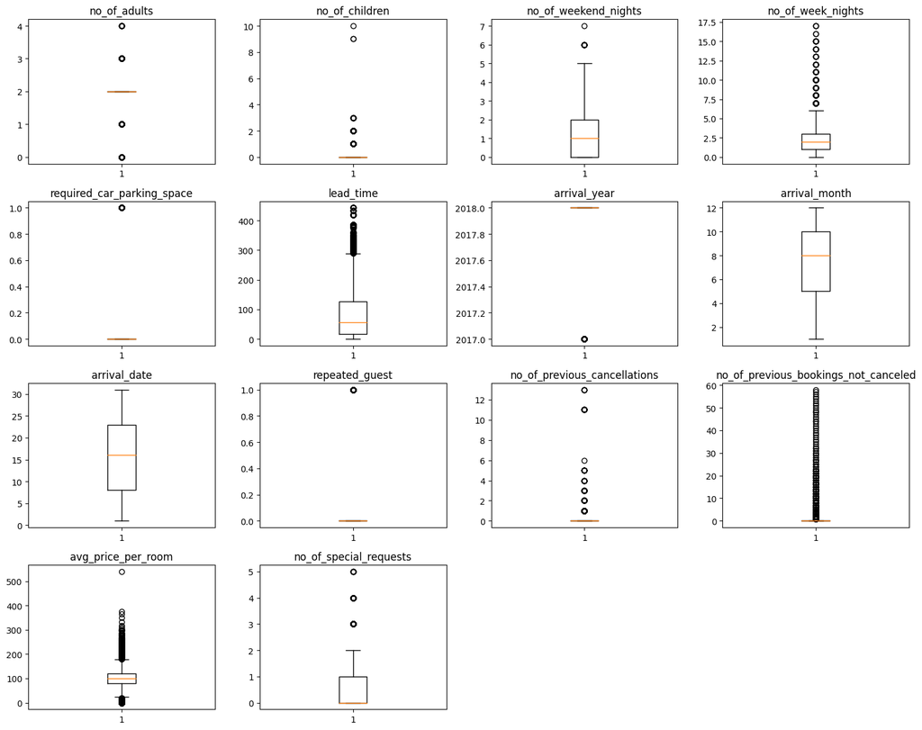

```python
# outlier detection
numeric_columns = data1.select_dtypes(include=np.number).columns.tolist()

plt.figure(figsize=(15, 12))

for i, variable in enumerate(numeric_columns):
    plt.subplot(4, 4, i + 1)
    plt.boxplot(data1[variable], whis=1.5)
    # switching from data4 to data1 because total_nights will have high multicolinearity
    plt.tight_layout()
    plt.title(variable)

plt.show()
```

- We will not treat them as they are proper values.

```python
# changing the target variable into 1's and 0's
data1['booking_status_binary'] = data1['booking_status'].map({'Canceled': 1, 'Not_Canceled': 0})
data1 = data1.drop(columns=['booking_status'])
```

```python
X = data1.drop(["booking_status_binary"], axis=1)
y = data1["booking_status_binary"]

print(X.head())
print(y.head())
```

```
   no_of_adults  no_of_children  no_of_weekend_nights  no_of_week_nights  \
0             2               0                     1                  2
1             2               0                     2                  3
2             1               0                     2                  1
3             2               0                     0                  2
4             2               0                     1                  1

  type_of_meal_plan  required_car_parking_space room_type_reserved  lead_time  \
0       Meal Plan 1                           0        Room_Type 1        224
1      Not Selected                           0        Room_Type 1          5
2       Meal Plan 1                           0        Room_Type 1          1
3       Meal Plan 1                           0        Room_Type 1        211
4      Not Selected                           0        Room_Type 1         48

   arrival_year  arrival_month  arrival_date market_segment_type  \
```

[output cut: 32 more lines]

```python
# next, let's add that constant to the data
X = sm.add_constant(X)
```

```python
# next, create dummy variables
X = pd.get_dummies(
    X,
    columns=X.select_dtypes(include=["object", "category"]).columns.tolist(),
    drop_first=True
)
X.head()
```

|  | const | no_of_adults | no_of_children | no_of_weekend_nights | no_of_week_nights | required_car_parking_space | lead_time | arrival_year | arrival_month | arrival_date | repeated_guest | no_of_previous_cancellations | no_of_previous_bookings_not_canceled | avg_price_per_room | no_of_special_requests | type_of_meal_plan_Meal Plan 2 | type_of_meal_plan_Meal Plan 3 | type_of_meal_plan_Not Selected | room_type_reserved_Room_Type 2 | room_type_reserved_Room_Type 3 | room_type_reserved_Room_Type 4 | room_type_reserved_Room_Type 5 | room_type_reserved_Room_Type 6 | room_type_reserved_Room_Type 7 | market_segment_type_Complementary | market_segment_type_Corporate | market_segment_type_Offline | market_segment_type_Online |
| --- | --- | --- | --- | --- | --- | --- | --- | --- | --- | --- | --- | --- | --- | --- | --- | --- | --- | --- | --- | --- | --- | --- | --- | --- | --- | --- | --- | --- |
| 0 | 1.00000 | 2 | 0 | 1 | 2 | 0 | 224 | 2017 | 10 | 2 | 0 | 0 | 0 | 65.00000 | 0 | False | False | False | False | False | False | False | False | False | False | False | True | False |
| 1 | 1.00000 | 2 | 0 | 2 | 3 | 0 | 5 | 2018 | 11 | 6 | 0 | 0 | 0 | 106.68000 | 1 | False | False | True | False | False | False | False | False | False | False | False | False | True |
| 2 | 1.00000 | 1 | 0 | 2 | 1 | 0 | 1 | 2018 | 2 | 28 | 0 | 0 | 0 | 60.00000 | 0 | False | False | False | False | False | False | False | False | False | False | False | False | True |
| 3 | 1.00000 | 2 | 0 | 0 | 2 | 0 | 211 | 2018 | 5 | 20 | 0 | 0 | 0 | 100.00000 | 0 | False | False | False | False | False | False | False | False | False | False | False | False | True |
| 4 | 1.00000 | 2 | 0 | 1 | 1 | 0 | 48 | 2018 | 4 | 11 | 0 | 0 | 0 | 94.50000 | 0 | False | False | True | False | False | False | False | False | False | False | False | False | True |

```python
# converting bool and into to float
X = X.astype(float)
X.head()
```

|  | const | no_of_adults | no_of_children | no_of_weekend_nights | no_of_week_nights | required_car_parking_space | lead_time | arrival_year | arrival_month | arrival_date | repeated_guest | no_of_previous_cancellations | no_of_previous_bookings_not_canceled | avg_price_per_room | no_of_special_requests | type_of_meal_plan_Meal Plan 2 | type_of_meal_plan_Meal Plan 3 | type_of_meal_plan_Not Selected | room_type_reserved_Room_Type 2 | room_type_reserved_Room_Type 3 | room_type_reserved_Room_Type 4 | room_type_reserved_Room_Type 5 | room_type_reserved_Room_Type 6 | room_type_reserved_Room_Type 7 | market_segment_type_Complementary | market_segment_type_Corporate | market_segment_type_Offline | market_segment_type_Online |
| --- | --- | --- | --- | --- | --- | --- | --- | --- | --- | --- | --- | --- | --- | --- | --- | --- | --- | --- | --- | --- | --- | --- | --- | --- | --- | --- | --- | --- |
| 0 | 1.00000 | 2.00000 | 0.00000 | 1.00000 | 2.00000 | 0.00000 | 224.00000 | 2017.00000 | 10.00000 | 2.00000 | 0.00000 | 0.00000 | 0.00000 | 65.00000 | 0.00000 | 0.00000 | 0.00000 | 0.00000 | 0.00000 | 0.00000 | 0.00000 | 0.00000 | 0.00000 | 0.00000 | 0.00000 | 0.00000 | 1.00000 | 0.00000 |
| 1 | 1.00000 | 2.00000 | 0.00000 | 2.00000 | 3.00000 | 0.00000 | 5.00000 | 2018.00000 | 11.00000 | 6.00000 | 0.00000 | 0.00000 | 0.00000 | 106.68000 | 1.00000 | 0.00000 | 0.00000 | 1.00000 | 0.00000 | 0.00000 | 0.00000 | 0.00000 | 0.00000 | 0.00000 | 0.00000 | 0.00000 | 0.00000 | 1.00000 |
| 2 | 1.00000 | 1.00000 | 0.00000 | 2.00000 | 1.00000 | 0.00000 | 1.00000 | 2018.00000 | 2.00000 | 28.00000 | 0.00000 | 0.00000 | 0.00000 | 60.00000 | 0.00000 | 0.00000 | 0.00000 | 0.00000 | 0.00000 | 0.00000 | 0.00000 | 0.00000 | 0.00000 | 0.00000 | 0.00000 | 0.00000 | 0.00000 | 1.00000 |
| 3 | 1.00000 | 2.00000 | 0.00000 | 0.00000 | 2.00000 | 0.00000 | 211.00000 | 2018.00000 | 5.00000 | 20.00000 | 0.00000 | 0.00000 | 0.00000 | 100.00000 | 0.00000 | 0.00000 | 0.00000 | 0.00000 | 0.00000 | 0.00000 | 0.00000 | 0.00000 | 0.00000 | 0.00000 | 0.00000 | 0.00000 | 0.00000 | 1.00000 |
| 4 | 1.00000 | 2.00000 | 0.00000 | 1.00000 | 1.00000 | 0.00000 | 48.00000 | 2018.00000 | 4.00000 | 11.00000 | 0.00000 | 0.00000 | 0.00000 | 94.50000 | 0.00000 | 0.00000 | 0.00000 | 1.00000 | 0.00000 | 0.00000 | 0.00000 | 0.00000 | 0.00000 | 0.00000 | 0.00000 | 0.00000 | 0.00000 | 1.00000 |

```python
# split the data into train and test
X_train, X_test, y_train, y_test = train_test_split(X, y, test_size=0.3, random_state=1)
```

```python
# checking to ensure the percentage of cancellations is approximately preserved
print("Shape of Training set : ", X_train.shape)
print("Shape of test set : ", X_test.shape)
print("Percentage of classes in training set:")
print(y_train.value_counts(normalize=True))
print("Percentage of classes in test set:")
print(y_test.value_counts(normalize=True))
```

```
Shape of Training set :  (25392, 28)
Shape of test set :  (10883, 28)
Percentage of classes in training set:
booking_status_binary
0   0.67064
1   0.32936
Name: proportion, dtype: float64
Percentage of classes in test set:
booking_status_binary
0   0.67638
1   0.32362
Name: proportion, dtype: float64
```

- I had to go through this section slowly because I kept running into issues and had to recode it 2 times
- We can see that the proportions are approximately preserved between the train and test data

**Secondary EDA is not necessary because we did not manipulate the data since the last EDA except for creating dummy variables**

## Building a Logistic Regression model

```python
# building a logistic regression model
logit = sm.Logit(y_train, X_train.astype(float))
lg = logit.fit()

print(lg.summary())
```

```
Warning: Maximum number of iterations has been exceeded.
         Current function value: 0.425036
         Iterations: 35
                             Logit Regression Results
=================================================================================
Dep. Variable:     booking_status_binary   No. Observations:                25392
Model:                             Logit   Df Residuals:                    25364
Method:                              MLE   Df Model:                           27
Date:                   Mon, 05 Aug 2024   Pseudo R-squ.:                  0.3293
Time:                           05:57:16   Log-Likelihood:                -10793.
converged:                         False   LL-Null:                       -16091.
Covariance Type:               nonrobust   LLR p-value:                     0.000
========================================================================================================
                                           coef    std err          z      P>|z|      [0.025      0.975]
--------------------------------------------------------------------------------------------------------
const                                 -924.5923    120.817     -7.653      0.000   -1161.390    -687.795
no_of_adults                             0.1135      0.038      3.017      0.003       0.040       0.187
no_of_children                           0.1563      0.057      2.732      0.006       0.044       0.268
no_of_weekend_nights                     0.1068      0.020      5.398      0.000       0.068       0.146
no_of_week_nights                        0.0398      0.012      3.239      0.001       0.016       0.064
required_car_parking_space              -1.5939      0.138    -11.561      0.000      -1.864      -1.324
lead_time                                0.0157      0.000     58.868      0.000       0.015       0.016
arrival_year                             0.4570      0.060      7.633      0.000       0.340       0.574
arrival_month                           -0.0415      0.006     -6.418      0.000      -0.054      -0.029
arrival_date                             0.0005      0.002      0.252      0.801      -0.003       0.004
repeated_guest                          -2.3469      0.617     -3.805      0.000      -3.556      -1.138
no_of_previous_cancellations             0.2664      0.086      3.108      0.002       0.098       0.434
no_of_previous_bookings_not_canceled    -0.1727      0.153     -1.131      0.258      -0.472       0.127
avg_price_per_room                       0.0188      0.001     25.404      0.000       0.017       0.020
no_of_special_requests                  -1.4690      0.030    -48.790      0.000      -1.528      -1.410
type_of_meal_plan_Meal Plan 2            0.1768      0.067      2.654      0.008       0.046       0.307
type_of_meal_plan_Meal Plan 3           17.8379   5057.771      0.004      0.997   -9895.211    9930.887
type_of_meal_plan_Not Selected           0.2782      0.053      5.245      0.000       0.174       0.382
room_type_reserved_Room_Type 2          -0.3610      0.131     -2.761      0.006      -0.617      -0.105
room_type_reserved_Room_Type 3          -0.0009      1.310     -0.001      0.999      -2.569       2.567
room_type_reserved_Room_Type 4          -0.2821      0.053     -5.305      0.000      -0.386      -0.178
room_type_reserved_Room_Type 5          -0.7176      0.209     -3.432      0.001      -1.127      -0.308
room_type_reserved_Room_Type 6          -0.9456      0.147     -6.434      0.000      -1.234      -0.658
room_type_reserved_Room_Type 7          -1.3964      0.293     -4.767      0.000      -1.971      -0.822
market_segment_type_Complementary      -41.8798   8.42e+05  -4.98e-05      1.000   -1.65e+06    1.65e+06
market_segment_type_Corporate           -1.1935      0.266     -4.487      0.000      -1.715      -0.672
market_segment_type_Offline             -2.1955      0.255     -8.625      0.000      -2.694      -1.697
market_segment_type_Online              -0.3990      0.251     -1.588      0.112      -0.891       0.093
========================================================================================================
```

## Checking Multicollinearity

- In order to make statistical inferences from a logistic regression model, it is important to ensure that there is no multicollinearity present in the data.

```python
# we will define a function to check VIF
def checking_vif(predictors):

    # Add a constant term to the predictors
    predictors_with_const = add_constant(predictors)

    # Calculate VIF
    vif = pd.DataFrame()
    vif["Feature"] = predictors_with_const.columns
    vif["VIF"] = [
        variance_inflation_factor(predictors_with_const.values, i)
        for i in range(predictors_with_const.shape[1])
    ]

    return vif

checking_vif(X_train)
```

|  | Feature | VIF |
| --- | --- | --- |
| 0 | const | 39468156.70600 |
| 1 | no_of_adults | 1.34815 |
| 2 | no_of_children | 1.97823 |
| 3 | no_of_weekend_nights | 1.06948 |
| 4 | no_of_week_nights | 1.09567 |
| 5 | required_car_parking_space | 1.03993 |
| 6 | lead_time | 1.39491 |
| 7 | arrival_year | 1.43083 |
| 8 | arrival_month | 1.27567 |
| 9 | arrival_date | 1.00674 |
| 10 | repeated_guest | 1.78352 |
| 11 | no_of_previous_cancellations | 1.39569 |
| 12 | no_of_previous_bookings_not_canceled | 1.65199 |
| 13 | avg_price_per_room | 2.05042 |
| 14 | no_of_special_requests | 1.24728 |
| 15 | type_of_meal_plan_Meal Plan 2 | 1.27185 |
| 16 | type_of_meal_plan_Meal Plan 3 | 1.02522 |
| 17 | type_of_meal_plan_Not Selected | 1.27218 |
| 18 | room_type_reserved_Room_Type 2 | 1.10144 |
| 19 | room_type_reserved_Room_Type 3 | 1.00330 |
| 20 | room_type_reserved_Room_Type 4 | 1.36152 |
| 21 | room_type_reserved_Room_Type 5 | 1.02781 |
| 22 | room_type_reserved_Room_Type 6 | 1.97307 |
| 23 | room_type_reserved_Room_Type 7 | 1.11512 |
| 24 | market_segment_type_Complementary | 4.50011 |
| 25 | market_segment_type_Corporate | 16.92844 |
| 26 | market_segment_type_Offline | 64.11392 |
| 27 | market_segment_type_Online | 71.17643 |

- We have several features with high VIF scores let's try dropping each one and then rerunning the logisitic model to see if it converges

```python
X_train2=X_train.drop(columns=['market_segment_type_Corporate'])
X_test2=X_test.drop(columns=['market_segment_type_Corporate'])
X_train3=X_train2.drop(columns=['market_segment_type_Offline'])
X_test3=X_test2.drop(columns=['market_segment_type_Offline'])
X_train4=X_train3.drop(columns=['market_segment_type_Online'])
X_test4=X_test3.drop(columns=['market_segment_type_Online'])

# building a logistic regression model for X_train2
logit = sm.Logit(y_train, X_train2.astype(float))
lg = logit.fit()

print(lg.summary())

# building a logisitic regression model for X_train3
logit = sm.Logit(y_train, X_train3.astype(float))
lg = logit.fit()

print(lg.summary())

# building a logistic regression model for X_train4
logit = sm.Logit(y_train, X_train4.astype(float))
lg = logit.fit()

print(lg.summary())
```

```
Warning: Maximum number of iterations has been exceeded.
         Current function value: 0.425393
         Iterations: 35
                             Logit Regression Results
=================================================================================
Dep. Variable:     booking_status_binary   No. Observations:                25392
Model:                             Logit   Df Residuals:                    25365
Method:                              MLE   Df Model:                           26
Date:                   Mon, 05 Aug 2024   Pseudo R-squ.:                  0.3287
Time:                           05:57:20   Log-Likelihood:                -10802.
converged:                         False   LL-Null:                       -16091.
Covariance Type:               nonrobust   LLR p-value:                     0.000
========================================================================================================
                                           coef    std err          z      P>|z|      [0.025      0.975]
--------------------------------------------------------------------------------------------------------
const                                 -948.3512    120.537     -7.868      0.000   -1184.599    -712.104
no_of_adults                             0.1045      0.038      2.785      0.005       0.031       0.178
no_of_children                           0.1551      0.057      2.714      0.007       0.043       0.267
no_of_weekend_nights                     0.1115      0.020      5.643      0.000       0.073       0.150
no_of_week_nights                        0.0424      0.012      3.450      0.001       0.018       0.066
required_car_parking_space              -1.5869      0.138    -11.508      0.000      -1.857      -1.317
lead_time                                0.0157      0.000     58.833      0.000       0.015       0.016
arrival_year                             0.4682      0.060      7.838      0.000       0.351       0.585
arrival_month                           -0.0406      0.006     -6.279      0.000      -0.053      -0.028
arrival_date                             0.0004      0.002      0.205      0.838      -0.003       0.004
repeated_guest                          -2.3353      0.619     -3.773      0.000      -3.548      -1.122
no_of_previous_cancellations             0.2669      0.086      3.117      0.002       0.099       0.435
no_of_previous_bookings_not_canceled    -0.1775      0.153     -1.158      0.247      -0.478       0.123
avg_price_per_room                       0.0187      0.001     25.397      0.000       0.017       0.020
no_of_special_requests                  -1.4695      0.030    -48.819      0.000      -1.528      -1.410
type_of_meal_plan_Meal Plan 2            0.1824      0.067      2.739      0.006       0.052       0.313
type_of_meal_plan_Meal Plan 3           16.5378   2618.484      0.006      0.995   -5115.596    5148.671
type_of_meal_plan_Not Selected           0.2822      0.053      5.321      0.000       0.178       0.386
room_type_reserved_Room_Type 2          -0.3577      0.131     -2.736      0.006      -0.614      -0.101
room_type_reserved_Room_Type 3           0.0039      1.309      0.003      0.998      -2.562       2.569
room_type_reserved_Room_Type 4          -0.2652      0.053     -4.996      0.000      -0.369      -0.161
room_type_reserved_Room_Type 5          -0.7450      0.209     -3.562      0.000      -1.155      -0.335
room_type_reserved_Room_Type 6          -0.9373      0.147     -6.382      0.000      -1.225      -0.649
room_type_reserved_Room_Type 7          -1.3887      0.293     -4.745      0.000      -1.962      -0.815
market_segment_type_Complementary      -37.7084   3.41e+05     -0.000      1.000   -6.68e+05    6.68e+05
```

[output cut: 71 more lines]

```
no_of_previous_cancellations             0.2424      0.091      2.651      0.008       0.063       0.422
no_of_previous_bookings_not_canceled    -0.1656      0.147     -1.128      0.259      -0.453       0.122
avg_price_per_room                       0.0228      0.001     31.825      0.000       0.021       0.024
no_of_special_requests                  -1.1605      0.027    -42.684      0.000      -1.214      -1.107
type_of_meal_plan_Meal Plan 2           -0.3585      0.062     -5.754      0.000      -0.481      -0.236
type_of_meal_plan_Meal Plan 3           13.8758   1343.857      0.010      0.992   -2620.036    2647.787
type_of_meal_plan_Not Selected           0.8231      0.049     16.758      0.000       0.727       0.919
room_type_reserved_Room_Type 2           0.1599      0.125      1.283      0.199      -0.084       0.404
room_type_reserved_Room_Type 3           0.0483      1.192      0.041      0.968      -2.287       2.384
room_type_reserved_Room_Type 4           0.0126      0.050      0.250      0.803      -0.086       0.111
room_type_reserved_Room_Type 5          -0.8686      0.199     -4.374      0.000      -1.258      -0.479
room_type_reserved_Room_Type 6          -1.0246      0.141     -7.280      0.000      -1.300      -0.749
room_type_reserved_Room_Type 7          -1.7033      0.289     -5.904      0.000      -2.269      -1.138
market_segment_type_Complementary      -23.9470   2110.515     -0.011      0.991   -4160.481    4112.587
========================================================================================================
```

- X_train2 had the highest pseudo r-squ. so we'll check the multicolinearity of that data set and see what we might drop next.

```python
checking_vif(X_train2)
```

|  | Feature | VIF |
| --- | --- | --- |
| 0 | const | 39398297.48593 |
| 1 | no_of_adults | 1.34412 |
| 2 | no_of_children | 1.97810 |
| 3 | no_of_weekend_nights | 1.06742 |
| 4 | no_of_week_nights | 1.09382 |
| 5 | required_car_parking_space | 1.03992 |
| 6 | lead_time | 1.39417 |
| 7 | arrival_year | 1.42861 |
| 8 | arrival_month | 1.27519 |
| 9 | arrival_date | 1.00672 |
| 10 | repeated_guest | 1.77838 |
| 11 | no_of_previous_cancellations | 1.39514 |
| 12 | no_of_previous_bookings_not_canceled | 1.64962 |
| 13 | avg_price_per_room | 2.04989 |
| 14 | no_of_special_requests | 1.24702 |
| 15 | type_of_meal_plan_Meal Plan 2 | 1.27165 |
| 16 | type_of_meal_plan_Meal Plan 3 | 1.02522 |
| 17 | type_of_meal_plan_Not Selected | 1.27173 |
| 18 | room_type_reserved_Room_Type 2 | 1.10139 |
| 19 | room_type_reserved_Room_Type 3 | 1.00330 |
| 20 | room_type_reserved_Room_Type 4 | 1.35423 |
| 21 | room_type_reserved_Room_Type 5 | 1.02717 |
| 22 | room_type_reserved_Room_Type 6 | 1.97298 |
| 23 | room_type_reserved_Room_Type 7 | 1.11512 |
| 24 | market_segment_type_Complementary | 1.37679 |
| 25 | market_segment_type_Offline | 5.78845 |
| 26 | market_segment_type_Online | 6.42358 |

- We can see the VIF scores for the market segment types are much lower now. Let's see if getting rid of one of them improves the pseduo r-squ. value

```python
X_train5=X_train2.drop(columns=['market_segment_type_Offline'])
X_test5=X_test2.drop(columns=['market_segment_type_Offline'])
X_train6=X_train2.drop(columns=['market_segment_type_Online'])
X_test6=X_test2.drop(columns=['market_segment_type_Online'])

# building a logistic regression model for X_train5
logit = sm.Logit(y_train, X_train5.astype(float))
lg = logit.fit()

print(lg.summary())

# building a logistic regression model for X_train6
logit = sm.Logit(y_train, X_train6.astype(float))
lg = logit.fit()

print(lg.summary())
```

```
Warning: Maximum number of iterations has been exceeded.
         Current function value: 0.427558
         Iterations: 35
                             Logit Regression Results
=================================================================================
Dep. Variable:     booking_status_binary   No. Observations:                25392
Model:                             Logit   Df Residuals:                    25366
Method:                              MLE   Df Model:                           25
Date:                   Mon, 05 Aug 2024   Pseudo R-squ.:                  0.3253
Time:                           05:57:22   Log-Likelihood:                -10857.
converged:                         False   LL-Null:                       -16091.
Covariance Type:               nonrobust   LLR p-value:                     0.000
========================================================================================================
                                           coef    std err          z      P>|z|      [0.025      0.975]
--------------------------------------------------------------------------------------------------------
const                                 -982.1619    120.344     -8.161      0.000   -1218.031    -746.293
no_of_adults                             0.0528      0.037      1.426      0.154      -0.020       0.126
no_of_children                           0.1456      0.058      2.530      0.011       0.033       0.258
no_of_weekend_nights                     0.1035      0.020      5.264      0.000       0.065       0.142
no_of_week_nights                        0.0426      0.012      3.480      0.001       0.019       0.067
required_car_parking_space              -1.5519      0.137    -11.301      0.000      -1.821      -1.283
lead_time                                0.0151      0.000     58.615      0.000       0.015       0.016
arrival_year                             0.4846      0.060      8.124      0.000       0.368       0.601
arrival_month                           -0.0403      0.006     -6.252      0.000      -0.053      -0.028
arrival_date                             0.0013      0.002      0.671      0.502      -0.002       0.005
repeated_guest                          -1.9110      0.618     -3.092      0.002      -3.122      -0.700
no_of_previous_cancellations             0.2156      0.086      2.497      0.013       0.046       0.385
no_of_previous_bookings_not_canceled    -0.1449      0.140     -1.038      0.299      -0.418       0.129
avg_price_per_room                       0.0186      0.001     25.287      0.000       0.017       0.020
no_of_special_requests                  -1.4512      0.030    -48.706      0.000      -1.510      -1.393
type_of_meal_plan_Meal Plan 2            0.1160      0.066      1.769      0.077      -0.013       0.245
type_of_meal_plan_Meal Plan 3           23.8829   1.11e+05      0.000      1.000   -2.17e+05    2.17e+05
type_of_meal_plan_Not Selected           0.2670      0.053      5.069      0.000       0.164       0.370
room_type_reserved_Room_Type 2          -0.3563      0.130     -2.746      0.006      -0.611      -0.102
room_type_reserved_Room_Type 3          -0.0359      1.283     -0.028      0.978      -2.551       2.479
room_type_reserved_Room_Type 4          -0.2434      0.053     -4.602      0.000      -0.347      -0.140
room_type_reserved_Room_Type 5          -0.5659      0.205     -2.763      0.006      -0.967      -0.165
room_type_reserved_Room_Type 6          -0.9173      0.147     -6.253      0.000      -1.205      -0.630
room_type_reserved_Room_Type 7          -1.3602      0.292     -4.651      0.000      -1.933      -0.787
market_segment_type_Complementary      -34.5419   1.11e+05     -0.000      1.000   -2.18e+05    2.17e+05
```

[output cut: 29 more lines]

```
no_of_previous_bookings_not_canceled    -0.1969      0.161     -1.223      0.221      -0.512       0.119
avg_price_per_room                       0.0192      0.001     26.170      0.000       0.018       0.021
no_of_special_requests                  -1.4475      0.030    -48.418      0.000      -1.506      -1.389
type_of_meal_plan_Meal Plan 2            0.1763      0.067      2.641      0.008       0.045       0.307
type_of_meal_plan_Meal Plan 3            9.7001     86.740      0.112      0.911    -160.308     179.708
type_of_meal_plan_Not Selected           0.3517      0.052      6.745      0.000       0.250       0.454
room_type_reserved_Room_Type 2          -0.3008      0.131     -2.303      0.021      -0.557      -0.045
room_type_reserved_Room_Type 3           0.0386      1.305      0.030      0.976      -2.519       2.596
room_type_reserved_Room_Type 4          -0.2550      0.053     -4.818      0.000      -0.359      -0.151
room_type_reserved_Room_Type 5          -0.8611      0.210     -4.094      0.000      -1.273      -0.449
room_type_reserved_Room_Type 6          -0.9610      0.147     -6.560      0.000      -1.248      -0.674
room_type_reserved_Room_Type 7          -1.4485      0.292     -4.963      0.000      -2.021      -0.876
market_segment_type_Complementary      -27.8867   5.71e+04     -0.000      1.000   -1.12e+05    1.12e+05
market_segment_type_Offline             -1.7167      0.051    -33.701      0.000      -1.817      -1.617
========================================================================================================
```

- X_train6 saw the better improvement, let's check the VIF scores again.

```python
checking_vif(X_train6)
```

|  | Feature | VIF |
| --- | --- | --- |
| 0 | const | 39391371.31459 |
| 1 | no_of_adults | 1.29385 |
| 2 | no_of_children | 1.97411 |
| 3 | no_of_weekend_nights | 1.06190 |
| 4 | no_of_week_nights | 1.09043 |
| 5 | required_car_parking_space | 1.03791 |
| 6 | lead_time | 1.37696 |
| 7 | arrival_year | 1.42838 |
| 8 | arrival_month | 1.27376 |
| 9 | arrival_date | 1.00606 |
| 10 | repeated_guest | 1.60234 |
| 11 | no_of_previous_cancellations | 1.37925 |
| 12 | no_of_previous_bookings_not_canceled | 1.63907 |
| 13 | avg_price_per_room | 2.02139 |
| 14 | no_of_special_requests | 1.21439 |
| 15 | type_of_meal_plan_Meal Plan 2 | 1.27135 |
| 16 | type_of_meal_plan_Meal Plan 3 | 1.02521 |
| 17 | type_of_meal_plan_Not Selected | 1.22808 |
| 18 | room_type_reserved_Room_Type 2 | 1.09726 |
| 19 | room_type_reserved_Room_Type 3 | 1.00330 |
| 20 | room_type_reserved_Room_Type 4 | 1.35367 |
| 21 | room_type_reserved_Room_Type 5 | 1.02076 |
| 22 | room_type_reserved_Room_Type 6 | 1.97203 |
| 23 | room_type_reserved_Room_Type 7 | 1.11430 |
| 24 | market_segment_type_Complementary | 1.28198 |
| 25 | market_segment_type_Offline | 1.49616 |

- We have removed multicolinearity from the data set.

```python
#get rid of high p-values
cols = X_train6.columns.tolist()
max_p_value = 1

#create a loop that checks for sorts by p-values and gets rid of the highest p-value if it's bigger than 0.05
while len(cols) > 0:
    x_train6_aux = X_train6[cols]
    model = sm.Logit(y_train, x_train6_aux).fit(disp=False)
    p_values = model.pvalues
    max_p_value = max(p_values)
    feature_with_p_max = p_values.idxmax()
    if max_p_value > 0.05:
        cols.remove(feature_with_p_max)
    else:
        break
print(cols)
```

[output not shown]

```python
X_train7=X_train6[cols]
X_test7=X_test6[cols]

# building a logistic regression model for X_train7
logit = sm.Logit(y_train, X_train7.astype(float))
lg = logit.fit()

print(lg.summary())
```

```
Optimization terminated successfully.
         Current function value: 0.426960
         Iterations 11
                             Logit Regression Results
=================================================================================
Dep. Variable:     booking_status_binary   No. Observations:                25392
Model:                             Logit   Df Residuals:                    25371
Method:                              MLE   Df Model:                           20
Date:                   Mon, 05 Aug 2024   Pseudo R-squ.:                  0.3263
Time:                           05:57:26   Log-Likelihood:                -10841.
converged:                          True   LL-Null:                       -16091.
Covariance Type:               nonrobust   LLR p-value:                     0.000
==================================================================================================
                                     coef    std err          z      P>|z|      [0.025      0.975]
--------------------------------------------------------------------------------------------------
const                           -941.9158    120.118     -7.842      0.000   -1177.342    -706.490
no_of_adults                       0.1587      0.037      4.323      0.000       0.087       0.231
no_of_children                     0.1747      0.057      3.083      0.002       0.064       0.286
no_of_weekend_nights               0.1238      0.020      6.299      0.000       0.085       0.162
no_of_week_nights                  0.0464      0.012      3.788      0.000       0.022       0.070
required_car_parking_space        -1.5957      0.138    -11.571      0.000      -1.866      -1.325
lead_time                          0.0159      0.000     59.890      0.000       0.015       0.016
arrival_year                       0.4652      0.060      7.815      0.000       0.349       0.582
arrival_month                     -0.0426      0.006     -6.608      0.000      -0.055      -0.030
repeated_guest                    -3.1279      0.526     -5.948      0.000      -4.159      -2.097
no_of_previous_cancellations       0.2655      0.076      3.493      0.000       0.117       0.414
avg_price_per_room                 0.0196      0.001     27.025      0.000       0.018       0.021
no_of_special_requests            -1.4472      0.030    -48.429      0.000      -1.506      -1.389
type_of_meal_plan_Meal Plan 2      0.1626      0.067      2.438      0.015       0.032       0.293
type_of_meal_plan_Not Selected     0.3608      0.052      6.926      0.000       0.259       0.463
room_type_reserved_Room_Type 2    -0.2949      0.131     -2.260      0.024      -0.551      -0.039
room_type_reserved_Room_Type 4    -0.2611      0.053     -4.937      0.000      -0.365      -0.157
room_type_reserved_Room_Type 5    -0.8748      0.210     -4.170      0.000      -1.286      -0.464
room_type_reserved_Room_Type 6    -0.9828      0.146     -6.714      0.000      -1.270      -0.696
room_type_reserved_Room_Type 7    -1.4857      0.292     -5.093      0.000      -2.057      -0.914
market_segment_type_Offline       -1.7057      0.051    -33.532      0.000      -1.805      -1.606
==================================================================================================
```

- All high P-values have been removed AND the logisitic regression converged.

## Model performance evaluation

```
Confusion Matrix:
[[6530  831]
 [1329 2193]]

Classification Report:
              precision    recall  f1-score   support

           0       0.83      0.89      0.86      7361
           1       0.73      0.62      0.67      3522

    accuracy                           0.80     10883
   macro avg       0.78      0.75      0.76     10883
weighted avg       0.80      0.80      0.80     10883
```

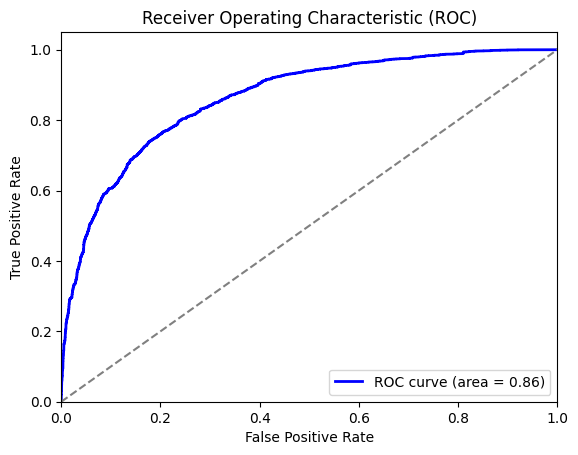

```
Log-Loss: 0.4235
```

```python
from sklearn.metrics import confusion_matrix, classification_report, roc_curve, roc_auc_score, log_loss
y_pred_prob = lg.predict(X_test7)
y_pred = (y_pred_prob > 0.5).astype(int)

# Calculate the confusion matrix
cm = confusion_matrix(y_test, y_pred)
print("Confusion Matrix:")
print(cm)

# Calculate classification report
report = classification_report(y_test, y_pred)
print("\nClassification Report:")
print(report)

# Calculate ROC curve and AUC
fpr, tpr, thresholds = roc_curve(y_test, y_pred_prob)
roc_auc = roc_auc_score(y_test, y_pred_prob)

# Plot ROC curve
plt.figure()
plt.plot(fpr, tpr, color='blue', lw=2, label=f'ROC curve (area = {roc_auc:.2f})')
plt.plot([0, 1], [0, 1], color='gray', linestyle='--')
plt.xlim([0.0, 1.0])
plt.ylim([0.0, 1.05])
plt.xlabel('False Positive Rate')
plt.ylabel('True Positive Rate')
plt.title('Receiver Operating Characteristic (ROC)')
plt.legend(loc="lower right")
plt.show()

# Calculate log-loss
logloss = log_loss(y_test, y_pred_prob)
print(f"\nLog-Loss: {logloss:.4f}")
```

```python
#find optimal threshold from the ROC curve
fpr, tpr, thresholds = roc_curve(y_train, lg.predict(X_train7))

optimal_idx = np.argmax(tpr - fpr)
optimal_threshold_auc_roc = thresholds[optimal_idx]
print(optimal_threshold_auc_roc)
```

```
0.36202962023005086
```

```python
# use this to build new confusion matrix
y_pred_optimal = (y_pred_prob >= optimal_threshold_auc_roc).astype(int)

cm = confusion_matrix(y_train, y_pred_optimal)
print("Confusion Matrix:")
print(cm)
```

[output not shown]

## Final Model Summary

I kept running into errors that did not occur during the lessons or the MLS.

## Building a Decision Tree model

```python
# split the data and create dummy variables
X = data1.drop(["booking_status_binary"], axis=1)
y = data1["booking_status_binary"]

X = pd.get_dummies(
    X,
    columns=X.select_dtypes(include=["object", "category"]).columns.tolist(),
    drop_first=True
)

X_train, X_test, y_train, y_test = train_test_split(X, y, test_size=0.3, random_state=1)
```

```python
print("Shape of Training set : ", X_train.shape)
print("Shape of test set : ", X_test.shape)
print("Percentage of classes in training set:")
print(y_train.value_counts(normalize=True))
print("Percentage of classes in test set:")
print(y_test.value_counts(normalize=True))
```

```
Shape of Training set :  (25392, 27)
Shape of test set :  (10883, 27)
Percentage of classes in training set:
booking_status_binary
0   0.67064
1   0.32936
Name: proportion, dtype: float64
Percentage of classes in test set:
booking_status_binary
0   0.67638
1   0.32362
Name: proportion, dtype: float64
```

- The proportions are essentially equal

```python
model0 = DecisionTreeClassifier(random_state=1)
model0.fit(X_train, y_train)
```

```
DecisionTreeClassifier(random_state=1)
```

```python
# this function will give us accuracy, recall, precision, and the f1 score
def model_performance_classification_sklearn(model, predictors, target):
    """
    Function to compute different metrics to check classification model performance

    model: classifier
    predictors: independent variables
    target: dependent variable
    """

    # predicting using the independent variables
    pred = model.predict(predictors)

    acc = accuracy_score(target, pred)  # to compute Accuracy
    recall = recall_score(target, pred)  # to compute Recall
    precision = precision_score(target, pred)  # to compute Precision
    f1 = f1_score(target, pred)  # to compute F1-score

    # creating a dataframe of metrics
    df_perf = pd.DataFrame(
        {"Accuracy": acc, "Recall": recall, "Precision": precision, "F1": f1,},
        index=[0],
    )

    return df_perf
```

```python
# this function plots a confusion matrix
def confusion_matrix_sklearn(model, predictors, target):
    """
    To plot the confusion_matrix with percentages

    model: classifier
    predictors: independent variables
    target: dependent variable
    """
    y_pred = model.predict(predictors)
    cm = confusion_matrix(target, y_pred)
    labels = np.asarray(
        [
            ["{0:0.0f}".format(item) + "\n{0:.2%}".format(item / cm.flatten().sum())]
            for item in cm.flatten()
        ]
    ).reshape(2, 2)

    plt.figure(figsize=(6, 4))
    sns.heatmap(cm, annot=labels, fmt="")
    plt.ylabel("True label")
    plt.xlabel("Predicted label")
```

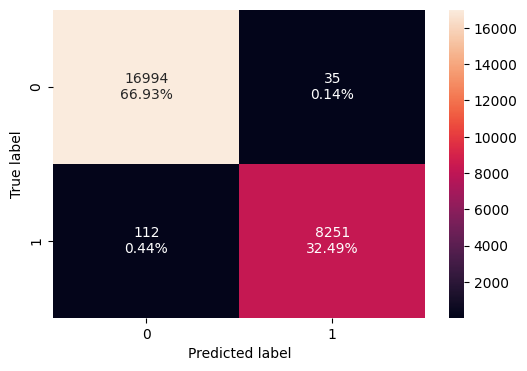

```python
confusion_matrix_sklearn(model0, X_train, y_train)
```

```python
decision_tree_perf_train_without = model_performance_classification_sklearn(
    model0, X_train, y_train
)
decision_tree_perf_train_without
```

|  | Accuracy | Recall | Precision | F1 |
| --- | --- | --- | --- | --- |
| 0 | 0.99421 | 0.98661 | 0.99578 | 0.99117 |

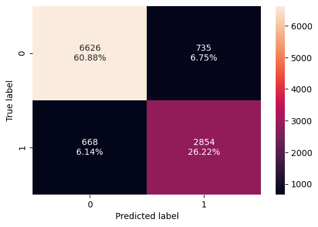

```python
confusion_matrix_sklearn(model0, X_test, y_test)
```

```python
decision_tree_perf_test_without = model_performance_classification_sklearn(
    model0, X_test, y_test
)
decision_tree_perf_test_without
```

|  | Accuracy | Recall | Precision | F1 |
| --- | --- | --- | --- | --- |
| 0 | 0.87108 | 0.81034 | 0.79521 | 0.80270 |

## Do we need to prune the tree?

- The accuracy, recall, recision, and F1 are all lower for the test data which means the training data is capturing too much noise. Let's try pre-pruning.

```python
# Pre-pruning
# Choose the type of classifier.
estimator = DecisionTreeClassifier(random_state=1)

# Grid of parameters to choose from
parameters = {
    "class_weight": [None, "balanced"],
    "max_depth": np.arange(2, 7, 2),
    "max_leaf_nodes": [50, 75, 150, 250],
    "min_samples_split": [10, 30, 50, 70],
}

# Type of scoring used to compare parameter combinations
acc_scorer = make_scorer(recall_score)

# Run the grid search
grid_obj = GridSearchCV(estimator, parameters, scoring=acc_scorer, cv=5)
grid_obj = grid_obj.fit(X_train, y_train)

# Set the clf to the best combination of parameters
estimator = grid_obj.best_estimator_

# Fit the best algorithm to the data.
estimator.fit(X_train, y_train)
```

```
DecisionTreeClassifier(class_weight='balanced', max_depth=2, max_leaf_nodes=50,
                       min_samples_split=10, random_state=1)
```

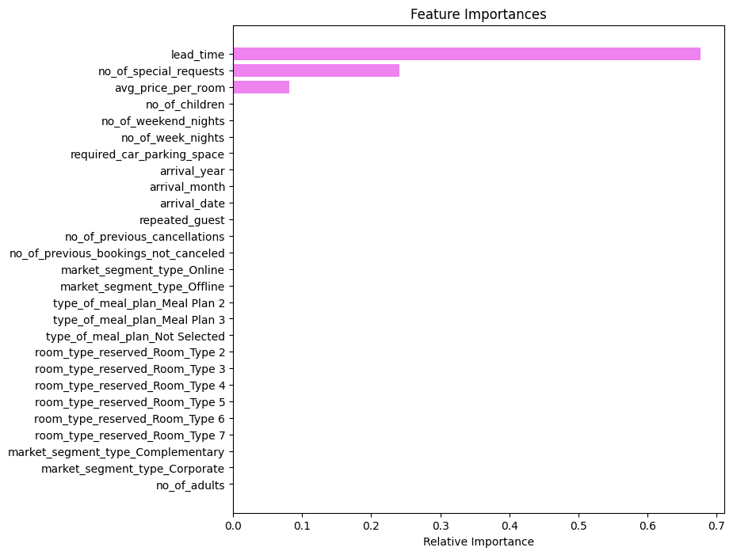

```python
# importance of features in the tree building
feature_names = list(X_train.columns)
importances = estimator.feature_importances_
indices = np.argsort(importances)

plt.figure(figsize=(8, 8))
plt.title("Feature Importances")
plt.barh(range(len(indices)), importances[indices], color="violet", align="center")
plt.yticks(range(len(indices)), [feature_names[i] for i in indices])
plt.xlabel("Relative Importance")
plt.show()
```

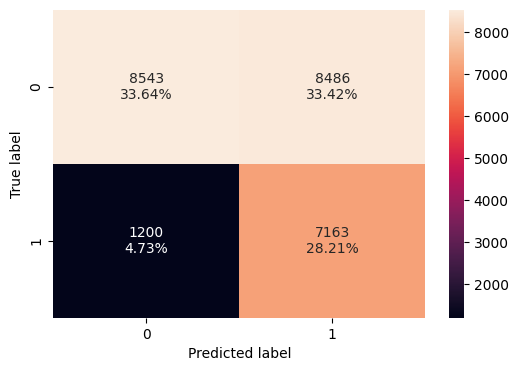

```python
confusion_matrix_sklearn(estimator, X_train, y_train)
```

```python
decision_tree_tune_perf_train = model_performance_classification_sklearn(
    estimator, X_train, y_train
)
decision_tree_tune_perf_train
```

|  | Accuracy | Recall | Precision | F1 |
| --- | --- | --- | --- | --- |
| 0 | 0.61854 | 0.85651 | 0.45773 | 0.59662 |

- The numbers went WAY down, let's see if the test data performs better.

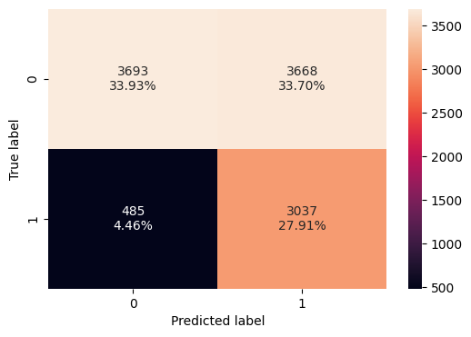

```python
confusion_matrix_sklearn(estimator, X_test, y_test)
```

```python
decision_tree_tune_perf_test = model_performance_classification_sklearn(
    estimator, X_test, y_test
)
decision_tree_tune_perf_test
```

|  | Accuracy | Recall | Precision | F1 |
| --- | --- | --- | --- | --- |
| 0 | 0.61840 | 0.86229 | 0.45295 | 0.59392 |

```python
clf = DecisionTreeClassifier(random_state=1, class_weight="balanced")
path = clf.cost_complexity_pruning_path(X_train, y_train)
ccp_alphas, impurities = abs(path.ccp_alphas), path.impurities
```

```python
pd.DataFrame(path)
```

|  | ccp_alphas | impurities |
| --- | --- | --- |
| 0 | 0.00000 | 0.00838 |
| 1 | -0.00000 | 0.00838 |
| 2 | 0.00000 | 0.00838 |
| 3 | 0.00000 | 0.00838 |
| 4 | 0.00000 | 0.00838 |
| ... | ... | ... |
| 1837 | 0.00890 | 0.32806 |
| 1838 | 0.00980 | 0.33786 |
| 1839 | 0.01272 | 0.35058 |
| 1840 | 0.03412 | 0.41882 |
| 1841 | 0.08118 | 0.50000 |

1842 rows × 2 columns

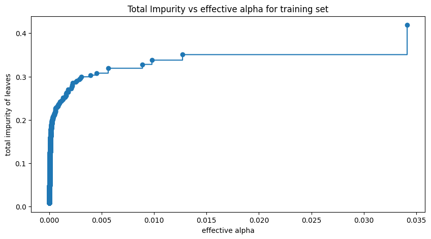

```python
fig, ax = plt.subplots(figsize=(10, 5))
ax.plot(ccp_alphas[:-1], impurities[:-1], marker="o", drawstyle="steps-post")
ax.set_xlabel("effective alpha")
ax.set_ylabel("total impurity of leaves")
ax.set_title("Total Impurity vs effective alpha for training set")
plt.show()
```

```python
clfs = []
for ccp_alpha in ccp_alphas:
    clf = DecisionTreeClassifier(
        random_state=1, ccp_alpha=ccp_alpha, class_weight="balanced"
    )
    clf.fit(X_train, y_train)
    clfs.append(clf)
print(
    "Number of nodes in the last tree is: {} with ccp_alpha: {}".format(
        clfs[-1].tree_.node_count, ccp_alphas[-1]
    )
)
```

```
Number of nodes in the last tree is: 1 with ccp_alpha: 0.08117914389136943
```

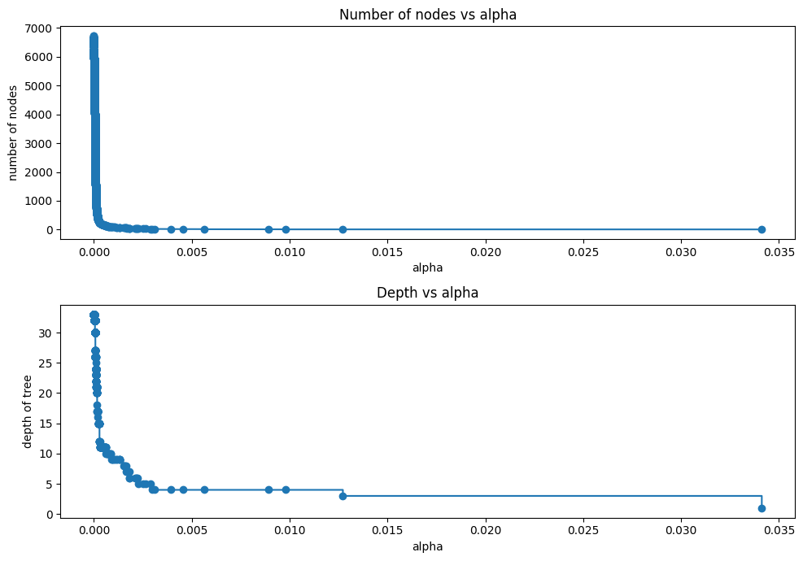

```python
clfs = clfs[:-1]
ccp_alphas = ccp_alphas[:-1]

node_counts = [clf.tree_.node_count for clf in clfs]
depth = [clf.tree_.max_depth for clf in clfs]
fig, ax = plt.subplots(2, 1, figsize=(10, 7))
ax[0].plot(ccp_alphas, node_counts, marker="o", drawstyle="steps-post")
ax[0].set_xlabel("alpha")
ax[0].set_ylabel("number of nodes")
ax[0].set_title("Number of nodes vs alpha")
ax[1].plot(ccp_alphas, depth, marker="o", drawstyle="steps-post")
ax[1].set_xlabel("alpha")
ax[1].set_ylabel("depth of tree")
ax[1].set_title("Depth vs alpha")
fig.tight_layout()
```

```python
#F1 score vs alpha for train and test sets
f1_train = []
for clf in clfs:
    pred_train = clf.predict(X_train)
    values_train = f1_score(y_train, pred_train)
    f1_train.append(values_train)

f1_test = []
for clf in clfs:
    pred_test = clf.predict(X_test)
    values_test = f1_score(y_test, pred_test)
    f1_test.append(values_test)
```

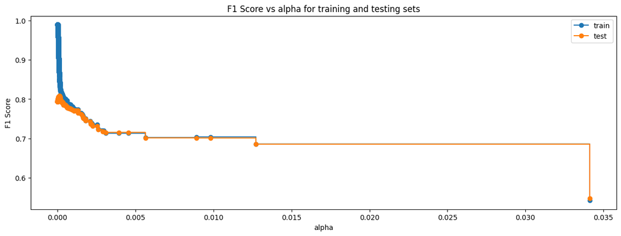

```python
fig, ax = plt.subplots(figsize=(15, 5))
ax.set_xlabel("alpha")
ax.set_ylabel("F1 Score")
ax.set_title("F1 Score vs alpha for training and testing sets")
ax.plot(ccp_alphas, f1_train, marker="o", label="train", drawstyle="steps-post")
ax.plot(ccp_alphas, f1_test, marker="o", label="test", drawstyle="steps-post")
ax.legend()
plt.show()
```

```python
# for this data set, maximizing F1 score seems best
index_best_model = np.argmax(f1_test)
best_model = clfs[index_best_model]
print(best_model)
```

```
DecisionTreeClassifier(ccp_alpha=0.0001226763315516701, class_weight='balanced',
                       random_state=1)
```

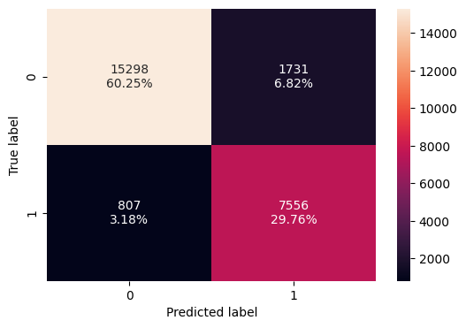

```python
confusion_matrix_sklearn(best_model, X_train, y_train)
```

```python
decision_tree_post_perf_train = model_performance_classification_sklearn(
    best_model, X_train, y_train
)
decision_tree_post_perf_train
```

|  | Accuracy | Recall | Precision | F1 |
| --- | --- | --- | --- | --- |
| 0 | 0.90005 | 0.90350 | 0.81361 | 0.85620 |

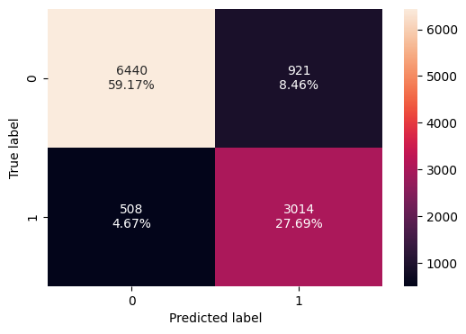

```python
confusion_matrix_sklearn(best_model, X_test, y_test)
```

```python
decision_tree_post_test = model_performance_classification_sklearn(
    best_model, X_test, y_test
)
decision_tree_post_test
```

|  | Accuracy | Recall | Precision | F1 |
| --- | --- | --- | --- | --- |
| 0 | 0.86869 | 0.85576 | 0.76595 | 0.80837 |

[figure not shown]

```python
plt.figure(figsize=(20, 10))

out = tree.plot_tree(
    best_model,
    feature_names=feature_names,
    filled=True,
    fontsize=9,
    node_ids=False,
    class_names=None,
)
for o in out:
    arrow = o.arrow_patch
    if arrow is not None:
        arrow.set_edgecolor("black")
        arrow.set_linewidth(1)
plt.show()
```

```python
print(tree.export_text(best_model, feature_names=feature_names, show_weights=True))
```

```
|--- lead_time <= 151.50
|   |--- no_of_special_requests <= 0.50
|   |   |--- market_segment_type_Online <= 0.50
|   |   |   |--- lead_time <= 90.50
|   |   |   |   |--- no_of_weekend_nights <= 0.50
|   |   |   |   |   |--- avg_price_per_room <= 196.50
|   |   |   |   |   |   |--- market_segment_type_Offline <= 0.50
|   |   |   |   |   |   |   |--- lead_time <= 16.50
|   |   |   |   |   |   |   |   |--- avg_price_per_room <= 68.50
|   |   |   |   |   |   |   |   |   |--- weights: [207.26, 10.63] class: 0
|   |   |   |   |   |   |   |   |--- avg_price_per_room >  68.50
|   |   |   |   |   |   |   |   |   |--- arrival_date <= 29.50
|   |   |   |   |   |   |   |   |   |   |--- no_of_adults <= 1.50
|   |   |   |   |   |   |   |   |   |   |   |--- truncated branch of depth 2
|   |   |   |   |   |   |   |   |   |   |--- no_of_adults >  1.50
|   |   |   |   |   |   |   |   |   |   |   |--- truncated branch of depth 5
|   |   |   |   |   |   |   |   |   |--- arrival_date >  29.50
|   |   |   |   |   |   |   |   |   |   |--- weights: [2.24, 7.59] class: 1
|   |   |   |   |   |   |   |--- lead_time >  16.50
|   |   |   |   |   |   |   |   |--- avg_price_per_room <= 135.00
|   |   |   |   |   |   |   |   |   |--- arrival_month <= 11.50
|   |   |   |   |   |   |   |   |   |   |--- repeated_guest <= 0.50
|   |   |   |   |   |   |   |   |   |   |   |--- truncated branch of depth 4
|   |   |   |   |   |   |   |   |   |   |--- repeated_guest >  0.50
|   |   |   |   |   |   |   |   |   |   |   |--- weights: [11.18, 0.00] class: 0
|   |   |   |   |   |   |   |   |   |--- arrival_month >  11.50
|   |   |   |   |   |   |   |   |   |   |--- weights: [21.62, 0.00] class: 0
|   |   |   |   |   |   |   |   |--- avg_price_per_room >  135.00
|   |   |   |   |   |   |   |   |   |--- weights: [0.00, 12.14] class: 1
|   |   |   |   |   |   |--- market_segment_type_Offline >  0.50
|   |   |   |   |   |   |   |--- weights: [1199.59, 0.00] class: 0
|   |   |   |   |   |--- avg_price_per_room >  196.50
|   |   |   |   |   |   |--- weights: [0.75, 25.81] class: 1
|   |   |   |   |--- no_of_weekend_nights >  0.50
|   |   |   |   |   |--- lead_time <= 68.50
|   |   |   |   |   |   |--- arrival_month <= 9.50
|   |   |   |   |   |   |   |--- avg_price_per_room <= 63.29
|   |   |   |   |   |   |   |   |--- arrival_date <= 20.50
|   |   |   |   |   |   |   |   |   |--- type_of_meal_plan_Not Selected <= 0.50
|   |   |   |   |   |   |   |   |   |   |--- weights: [41.75, 0.00] class: 0
```

[output cut: 651 more lines]

```
|   |   |   |   |   |   |--- weights: [5.96, 4.55] class: 0
|   |--- avg_price_per_room >  100.04
|   |   |--- arrival_month <= 11.50
|   |   |   |--- no_of_special_requests <= 2.50
|   |   |   |   |--- weights: [0.00, 3200.19] class: 1
|   |   |   |--- no_of_special_requests >  2.50
|   |   |   |   |--- weights: [23.11, 0.00] class: 0
|   |   |--- arrival_month >  11.50
|   |   |   |--- no_of_special_requests <= 0.50
|   |   |   |   |--- weights: [35.04, 0.00] class: 0
|   |   |   |--- no_of_special_requests >  0.50
|   |   |   |   |--- arrival_date <= 24.50
|   |   |   |   |   |--- weights: [3.73, 0.00] class: 0
|   |   |   |   |--- arrival_date >  24.50
|   |   |   |   |   |--- weights: [3.73, 22.77] class: 1
```

```python
importances = best_model.feature_importances_
indices = np.argsort(importances)
```

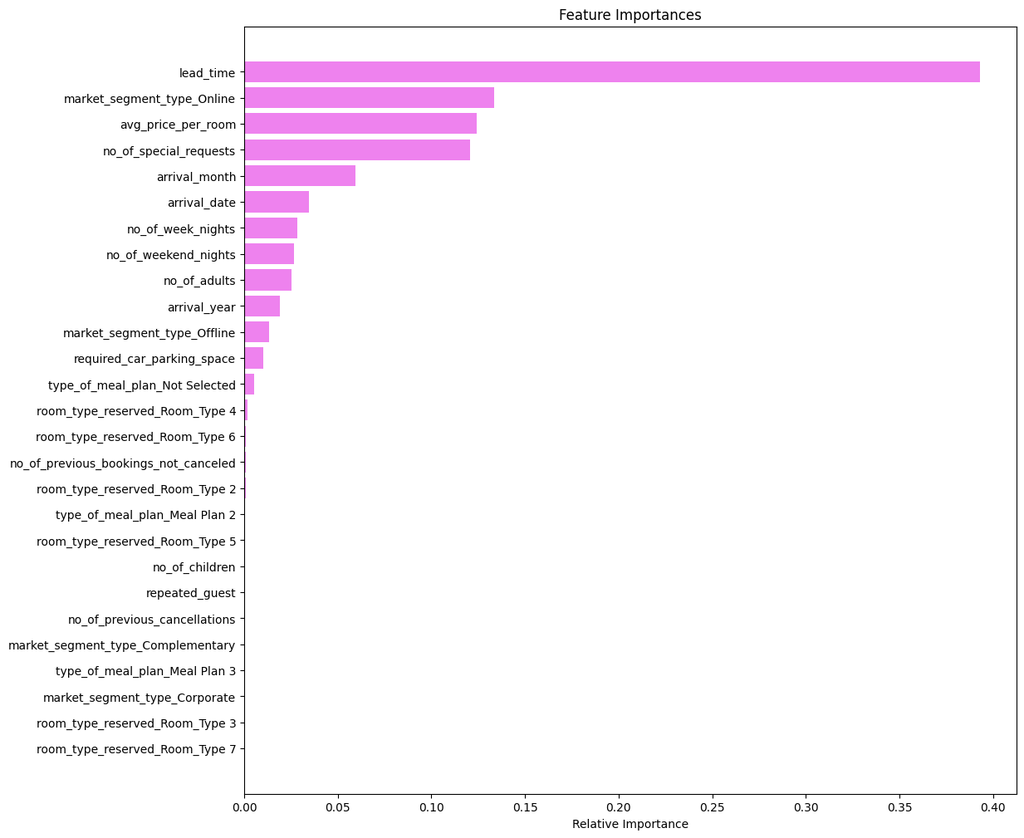

```python
plt.figure(figsize=(12, 12))
plt.title("Feature Importances")
plt.barh(range(len(indices)), importances[indices], color="violet", align="center")
plt.yticks(range(len(indices)), [feature_names[i] for i in indices])
plt.xlabel("Relative Importance")
plt.show()
```

## Model Performance Comparison and Conclusions

```python
# training performance comparison

models_train_comp_df = pd.concat(
    [
        decision_tree_perf_train_without.T,
        decision_tree_tune_perf_train.T,
        decision_tree_post_perf_train.T,
    ],
    axis=1,
)
models_train_comp_df.columns = [
    "Decision Tree sklearn",
    "Decision Tree (Pre-Pruning)",
    "Decision Tree (Post-Pruning)",
]
print("Training performance comparison:")
models_train_comp_df
```

```
Training performance comparison:
```

|  | Decision Tree sklearn | Decision Tree (Pre-Pruning) | Decision Tree (Post-Pruning) |
| --- | --- | --- | --- |
| Accuracy | 0.99421 | 0.61854 | 0.90005 |
| Recall | 0.98661 | 0.85651 | 0.90350 |
| Precision | 0.99578 | 0.45773 | 0.81361 |
| F1 | 0.99117 | 0.59662 | 0.85620 |

```python
# testing performance comparison

models_test_comp_df= pd.concat(
    [
        decision_tree_perf_test_without.T,
        decision_tree_tune_perf_test.T,
        decision_tree_post_test.T,
    ],
    axis=1,
)
models_test_comp_df.columns = [
    "Decision Tree sklearn",
    "Decision Tree (Pre-Pruning)",
    "Decision Tree (Post-Pruning)",
]
print("Testing performance comparison:")
models_test_comp_df
```

```
Testing performance comparison:
```

|  | Decision Tree sklearn | Decision Tree (Pre-Pruning) | Decision Tree (Post-Pruning) |
| --- | --- | --- | --- |
| Accuracy | 0.87108 | 0.61840 | 0.86869 |
| Recall | 0.81034 | 0.86229 | 0.85576 |
| Precision | 0.79521 | 0.45295 | 0.76595 |
| F1 | 0.80270 | 0.59392 | 0.80837 |

## Actionable Insights and Recommendations

```python
%shell jupyter nbconvert --to html '/content/drive/MyDrive/Python Foundations - GreatLearning/ENews_Express_Learner_Notebook_Full_Code.ipynb'
```